# Car Models Project

## Introduzione

Attraverso questo progetto ho voluto studiare le relazioni tra le caratteristiche principali dei motori delle automobili, dal 1950 ad oggi.

Le variabili considerate sono:

- potenza (cv);
- cilindrata (cc);
- rapporto cavalli per litro (HP/L);
- consumo carburante;
- segmento auto;

## Dataset utilizzato

I dati provengono dal sito Kaggle, il dataset originario è decisamente ampio e data la presenza di notevoli informazioni non necessarie è stato ridotto e modellato.

### **Questioni studiate:**

- Analisi generale per cilindrata e cavalli;
- Analisi singola cilindrata e cavalli nel tempo;
- Cambiamento rapporto cavlli per litro nel tempo;
- Miglior segmento per prestazioni relative;
- Miglior segmento per consumi;
- Analisi complessiva segmenti;

## Prima analisi ai dati

Dipendenza tra cilindrata e potenza:

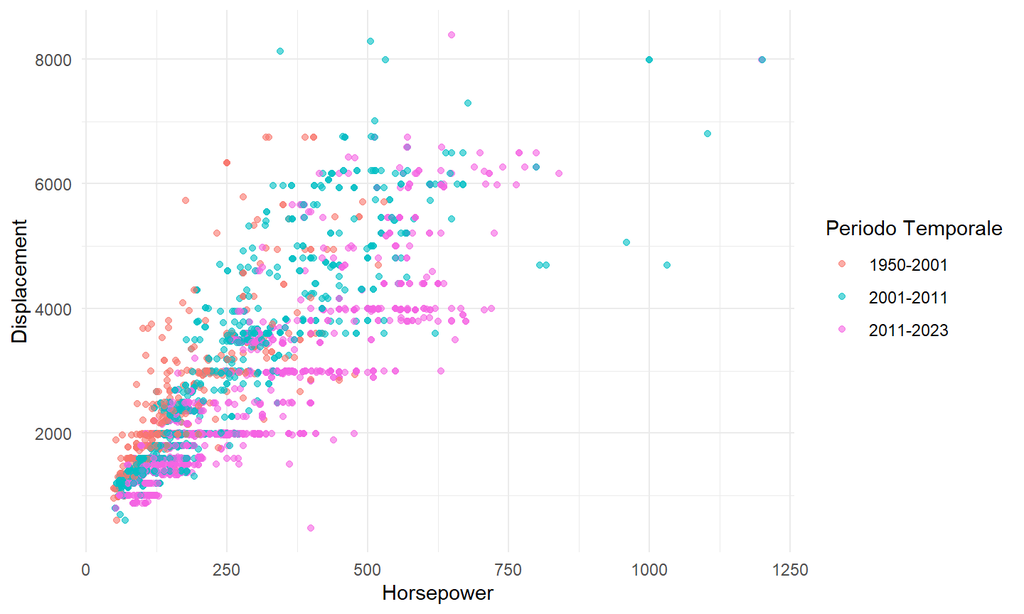

Nel corso degli anni lo sviluppo tecnologico ha portato le auto ad avere più cavalli e meno cilindrata.

Data la tendenza emersa segue un’analisi singola per i due valori.

## Analisi temporale singola

Il primo valore tende a diminuire, mentre nel secondo caso è presente una buona tendenza crescente.

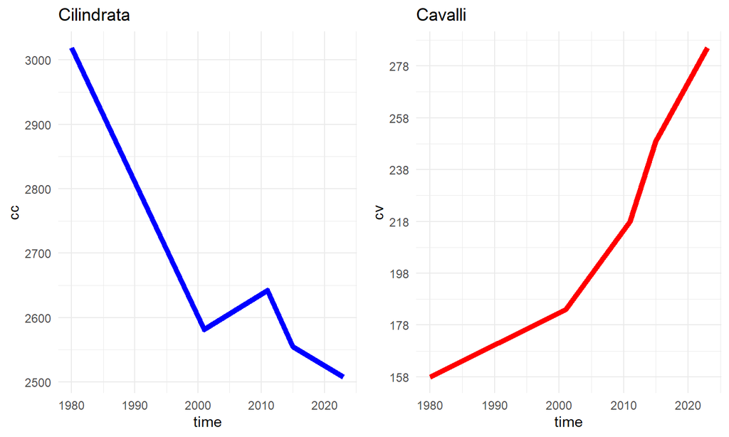

## Medie annuali Cavalli al litro con Normative Euro

L’introduzione di norme sulle emissioni sempre più stringenti ha portato ad un’elevata quantità di filtri sulla linea di scarico, che riducono però la potenza erogata.

Dunque le case produttrici, per mantenere i valori dei loro modelli, devono aumentare leggermente le prestazioni del motore. L’opzione più semplice è di aumentare la cilindrata e probabilmente anche per questo motivo il grafico dell’andamento di questo valore nel tempo, mostrava una riduzione relativamente contenuta.

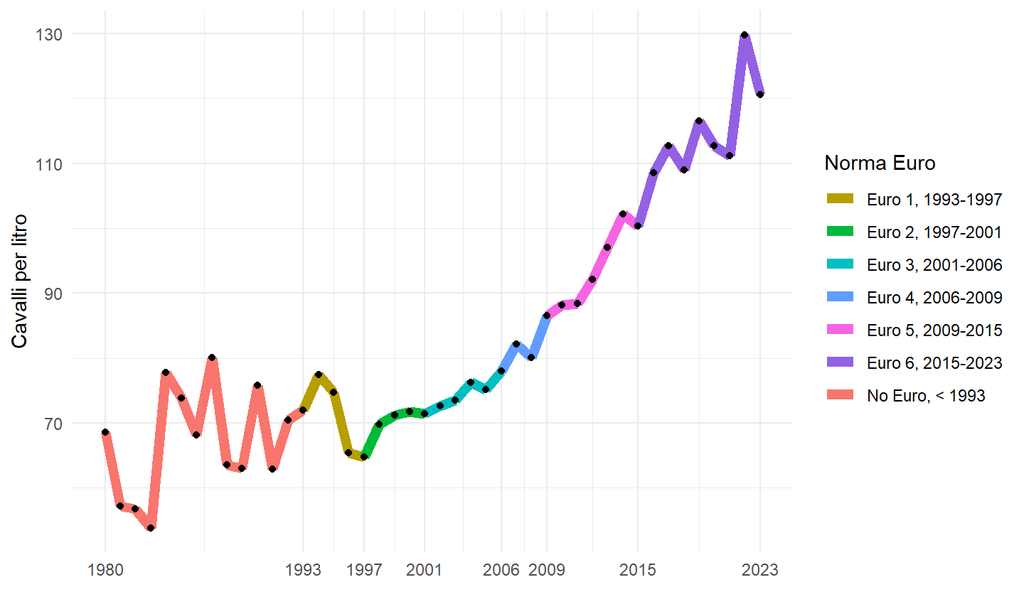

## Miglior segmento per prestazioni

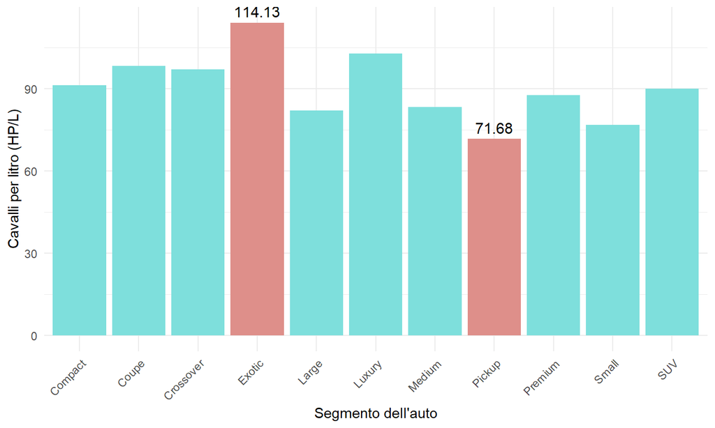

- **Segmento Migliore:** Exotic (es. LAMBORGHINI Aventador SVJ, FERRARI SF90)
- **Segmento Peggiore:** Pickup (es. FORD Ranger, DODGE Ram)

Il prezzo elevato delle auto esotiche garantisce motori con prestazioni decisamente elevate.

Il segmento dei pickup è il peggiore in quanto l’aspetto importante per un motore di quel tipo è la coppia e non i cavalli.

## Miglior segmento per consumi

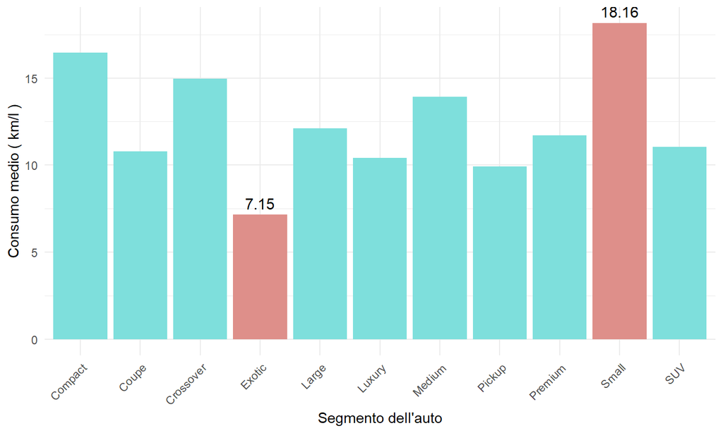

- **Segmento Migliore:** Small (es. HUNDAI i10, PEUGEOT 207)
- **Segmento Peggiore:** Exotic (es. LAMBORGHINI Aventador SVJ, FERRARI SF90)

## Analisi complessiva

Questo grafico riassume le informazioni più importanti analizzate fino ad ora. Pone in relazione i diversi segmenti di auto, utilizzando i cavalli per litro sull’asse x e il consumo del carburante sull’asse y. Inoltre la grandezza dei punti indica un’approssimazione del valore di cilindrata.

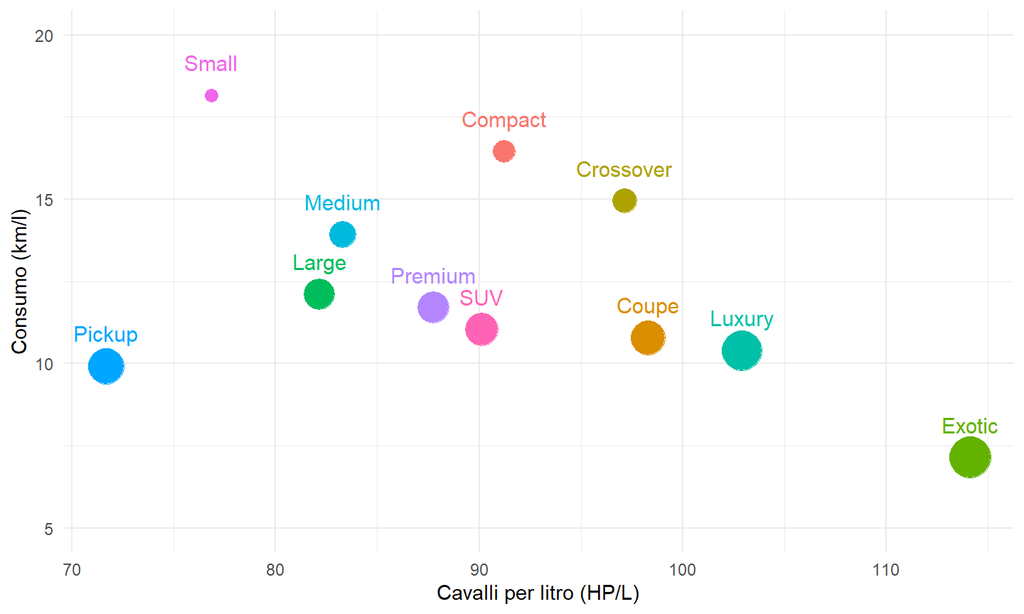

## Fine

Grazie per l’attenzione.